# 02-Grafikoetarako

## Dentsitatea

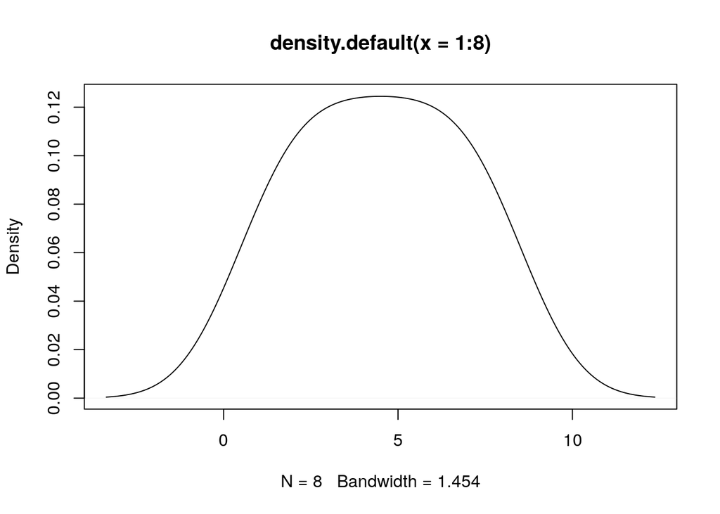

```r
plot(density(1:8))
```

Dentsitate grafiken arazoa sarri izaten da zabalera. Hori ere aurrez erabagi deikegu:

## Ardatzetako heina

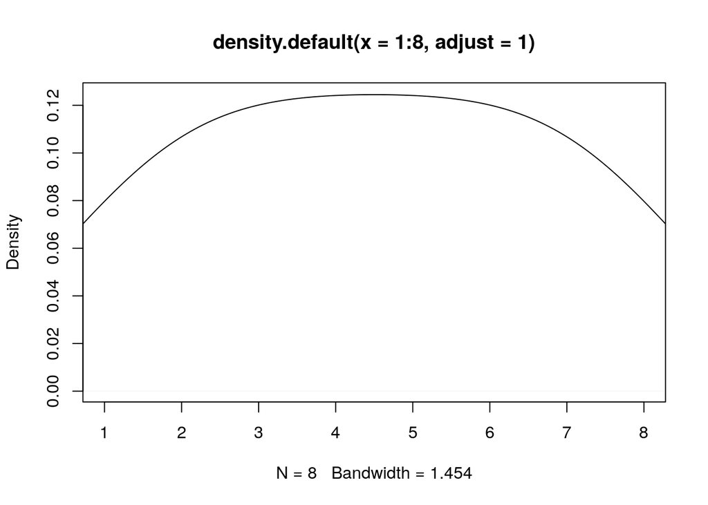

```r
plot(density(1:8, adjust = 1),
     xlim = c(1,8))
```

# Ariketa

Birsortu zure lehengo batzarreko data frame ha eta irudikatu aldagaiak banaka. Gero aztertu zein irudikatu ahal direan erlazioan eta bilatu alkarregaz aldagaiak binaka irudikatzeko moduak

Nirea:

```r
df.juanena <- structure(list(olentzerori.idatzi = c(TRUE, TRUE, TRUE, FALSE),
                             olentzerok.ezer.ekarri = structure(c(2L, 2L, 2L, 1L),
                                                                .Label = c("ikatza", "oparia"),
                                                                class = "factor"),
                             zenbat.pizza = c(3, 2, 3, 4),
                             zenbat.turroi = structure(c(2L, 2L, 1L, 3L),
                                                       .Label = c("gitxi", "nahiko", "asko"),
                                                       class = c("ordered", "factor"))),
                        class = "data.frame", row.names = c("nagusia", "txikia", "ama", "aita"))

knitr::kable(df.juanena)
```

|  | olentzerori.idatzi | olentzerok.ezer.ekarri | zenbat.pizza | zenbat.turroi |
| --- | --- | --- | --- | --- |
| nagusia | TRUE | oparia | 3 | nahiko |
| txikia | TRUE | oparia | 2 | nahiko |
| ama | TRUE | oparia | 3 | gitxi |
| aita | FALSE | ikatza | 4 | asko |

```r
## Egin eta azaldu
```

- Konpilatu amaitutakoan, [hemen](https://juanabasolo.github.io/Rikasi/02-Grafikoetarako.nb.html) nirea

# Bibliografiea

Chang, W. (2018). *R graphics cookbook: Practical recipes for visualizing data* (Second edition). O’Reilly.

> `ggplot` sisteman oinarritua gehiena

Correa, J. C., & González, N. (2002). *Gráficos Estadísticos con R*. Universidad Nacional. https://cran.r-project.org/doc/contrib/grafi3.pdf

> Hemen ikusten dugun sisteman oinarritua (`graphics`)

Hadley, W. (2016). *Ggplot2*. Springer Science+Business Media, LLC.

> `ggplot` sisteman oinarritua

Sarkar, D. (2008). *Lattice: Multivariate data visualization with R*. Springer.

> `lattice` sisteman oinarritua

Teutonico, D. (2015). *ggplot2 essentials: Explore the full range of ggplot2 plotting capabilities to create meaningful and spectacular graphs*. Packt Publishing.

> `ggplot` sisteman oinarritua

Venables, W. N., & Smith, D. M. (2002). *An introduction to R: A programming environment for data analysis and graphics. version 1.4.1*. Network Theory. https://cran.r-project.org/doc/manuals/R-intro.pdf

> Berez, 2019ko bertsinoa da estekakoa. Batez be oinarrizko instalazinotik begituta. Oso xehetuta dana; akaso, xehegi eta datu lar. 63. orrian hasten da grafiken ganekoa.